# Similarity Judgment Task Analysis: Adjs Abs-Conc

morgan moyer

2025-07-09

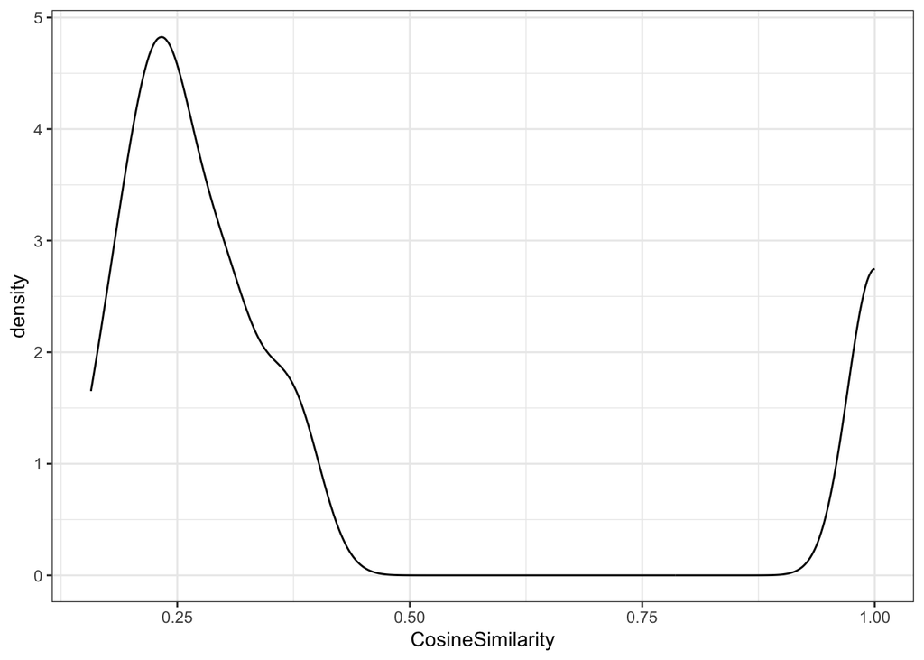

```r
ggplot(d, aes(CosineSimilarity)) +
  geom_density(alpha = .5)
```

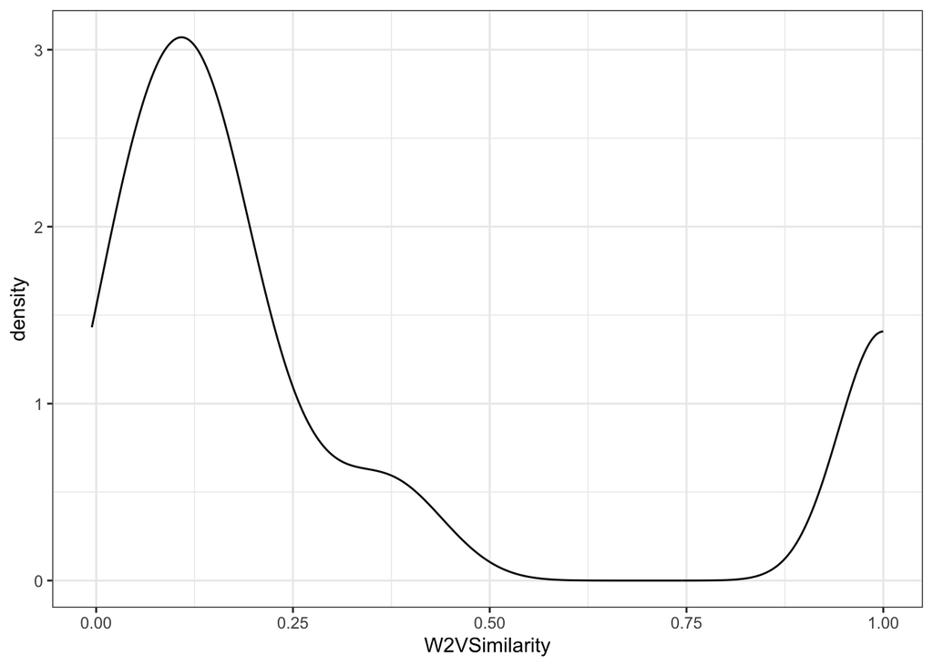

```r
ggplot(d, aes(W2VSimilarity)) +
  geom_density(alpha = .5)
```

```r
names(d)
```

```
## [1] "WordPair"         "X"                "ID.Ibex"          "Response"
## [5] "FeatureMatch"     "Word1"            "Word2"            "W2VSimilarity"
## [9] "CosineSimilarity"
```

```r
dcen <- d %>%
  mutate(WordPair = as.factor(WordPair),
         ID.Ibex = as.factor(ID.Ibex),
         FeatureMatch = as.factor(FeatureMatch),
         cResponse = as.numeric(Response)-mean(as.numeric(Response)))

m <- lmer(cResponse ~ FeatureMatch + (1|WordPair) + (1+FeatureMatch|ID.Ibex), data = dcen)
```

```
## boundary (singular) fit: see help('isSingular')
```

```r
summary(m)
```

```
## Linear mixed model fit by REML. t-tests use Satterthwaite's method [
## lmerModLmerTest]
## Formula: cResponse ~ FeatureMatch + (1 | WordPair) + (1 + FeatureMatch |
##     ID.Ibex)
##    Data: dcen
##
## REML criterion at convergence: 3751.7
##
## Scaled residuals:
##     Min      1Q  Median      3Q     Max
## -2.9330 -0.3756 -0.0665  0.1911  4.7741
##
## Random effects:
##  Groups   Name                            Variance Std.Dev. Corr
##  WordPair (Intercept)                     143.77   11.990
##  ID.Ibex  (Intercept)                      33.80    5.813
##           FeatureMatchMaxMatch             85.82    9.264   -0.06
##           FeatureMatchMaxMismatch          12.20    3.493   -0.77  0.69
##           FeatureMatchSelfPair             96.88    9.843   -0.81 -0.04  0.57
##           FeatureMatchValenceMatchingOnly  26.34    5.132    0.49  0.83  0.18
##  Residual                                 191.31   13.832
##
##
##
##
##
##
##  -0.41
##
## Number of obs: 450, groups:  WordPair, 50; ID.Ibex, 9
##
## Fixed effects:
##                                 Estimate Std. Error      df t value Pr(>|t|)
## (Intercept)                      -22.471      4.501  40.793  -4.993 1.16e-05
## FeatureMatchMaxMatch              19.656      6.522  37.852   3.014  0.00459
## FeatureMatchMaxMismatch           -2.689      5.862  45.142  -0.459  0.64864
## FeatureMatchSelfPair              90.800      6.616  36.530  13.725 5.45e-16
## FeatureMatchValenceMatchingOnly    4.589      5.994  45.185   0.766  0.44792
##
## (Intercept)                     ***
## FeatureMatchMaxMatch            **
## FeatureMatchMaxMismatch
## FeatureMatchSelfPair            ***
## FeatureMatchValenceMatchingOnly
## ---
## Signif. codes:  0 '***' 0.001 '**' 0.01 '*' 0.05 '.' 0.1 ' ' 1
##
## Correlation of Fixed Effects:
##             (Intr) FtrMtchMxMt FtrMtchMxMs FtrMSP
## FtrMtchMxMt -0.575
## FtrMtchMxMs -0.691  0.496
## FtrMtchSlfP -0.728  0.373       0.481
## FtrMtchVlMO -0.551  0.535       0.480       0.358
## optimizer (nloptwrap) convergence code: 0 (OK)
## boundary (singular) fit: see help('isSingular')
```

### Plot fixed effect estimates with confidence intervals

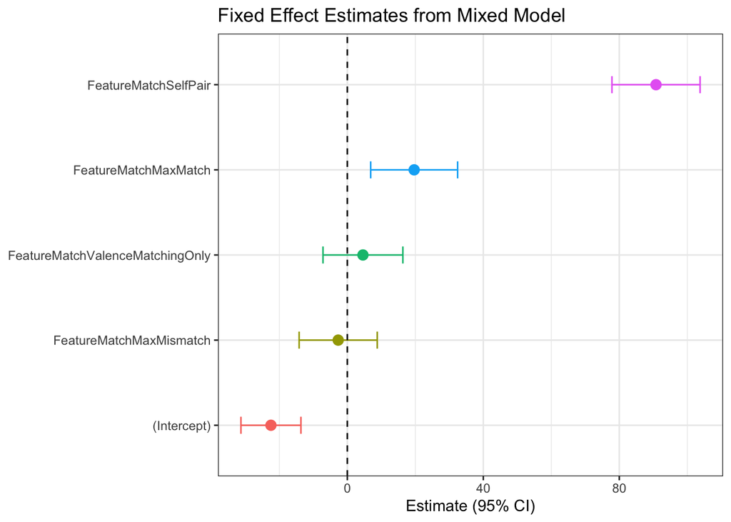

```r
# Tidy the model output
coefs <- tidy(m, effects = "fixed")
# Reorder by effect size for prettier plotting
coefs$term <- factor(coefs$term, levels = coefs$term[order(coefs$estimate)])

# Then replot
ggplot(coefs, aes(x = estimate, y = term, color = term)) +
  geom_point(size = 3) +
  geom_errorbarh(aes(xmin = estimate - 1.96 * std.error,
                     xmax = estimate + 1.96 * std.error), height = 0.2) +
  geom_vline(xintercept = 0, linetype = "dashed") +
  # theme_minimal(base_size = 14) +
  labs(title = "Fixed Effect Estimates from Mixed Model",
       x = "Estimate (95% CI)", y = NULL) +
  theme(legend.position="none")
```

### Plot predicted values vs. predictors

You can create a dataset of predicted values from your model and plot how the response changes with predictors:

```r
newdata <- expand.grid(
  FeatureMatch = levels(dcen$FeatureMatch))
```

2. Get predicted values and standard errors from the model

```r
pred <- predict(m, newdata = newdata, re.form = NA, se.fit = TRUE)
```

3. Add predictions and confidence intervals to newdata

```r
newdata$fit <- pred$fit
newdata$se <- pred$se.fit
newdata <- newdata %>%
  mutate(
    conf.low = fit - 1.96 * se,
    conf.high = fit + 1.96 * se
  )
```

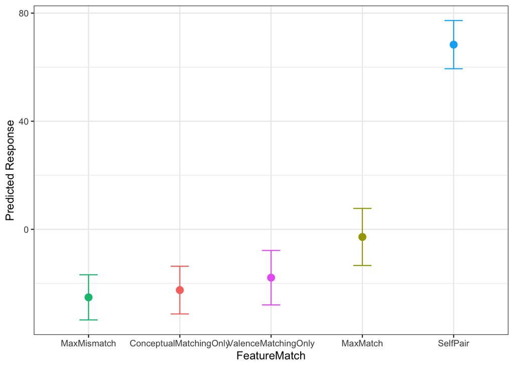

```r
ggplot(newdata, aes(x = reorder(FeatureMatch,fit), y = fit, color = FeatureMatch, fill = FeatureMatch)) +
  geom_point(size = 3) +
  geom_errorbar(aes(ymin = conf.low, ymax = conf.high), width = 0.2) +
  # theme_minimal() +
  labs(x = "FeatureMatch", y = "Predicted Response", color = "FeatureMatch", fill = "FeatureMatch") +
  theme(legend.position="none")
```

## You can visualize individual random effect estimates:

What you get from the plot: A visual summary of the variability in random effects across levels of your grouping factors.

Helps you identify:

Which groups (subjects/items) deviate strongly from the average effect,

How precise these deviations are,

Whether there are outliers or patterns in random effects.

Example interpretation: If a subject’s random intercept dot is far from zero with narrow error bars, that subject consistently differs from the average intercept with high certainty.

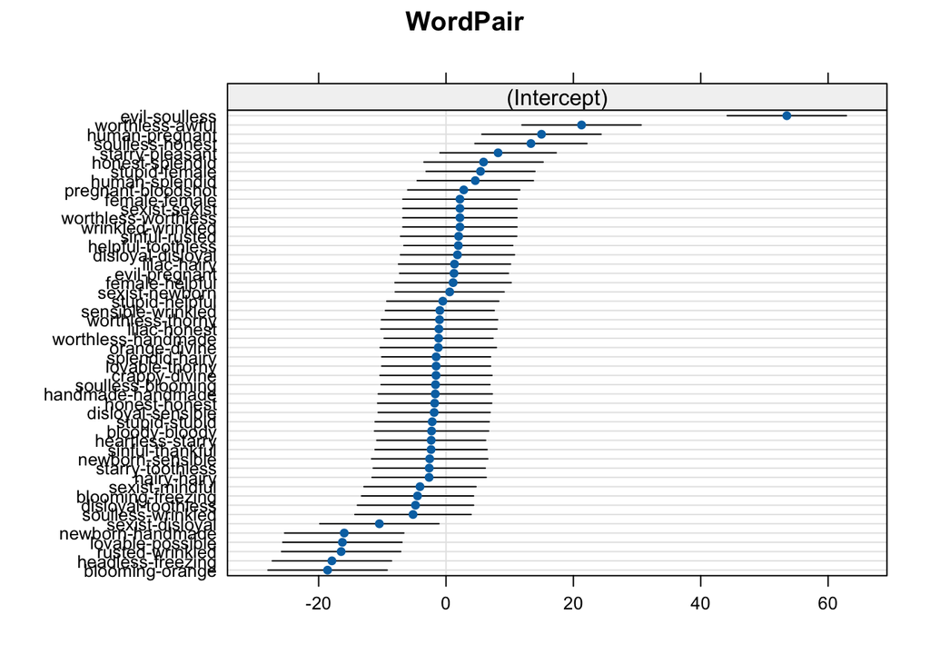

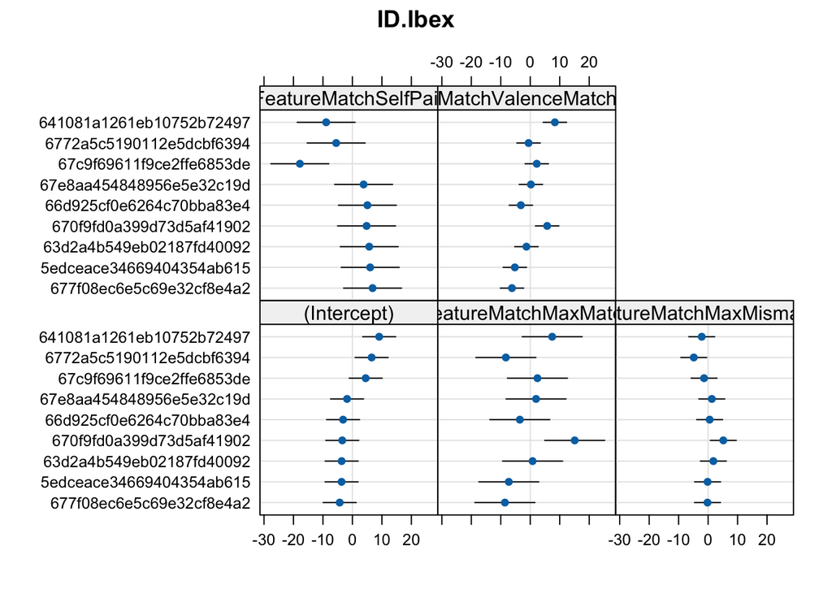

```r
dotplot(ranef(m, condVar=TRUE))
```

## Check model diagnostics

For residuals, fitted vs residuals, etc.:

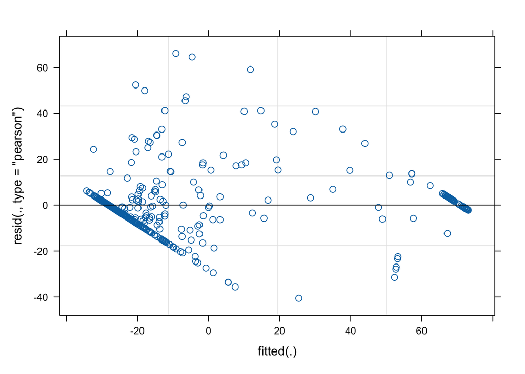

```r
plot(m)
```

# Does Similarity predict or interact with FeatureMatch?

## Cosine Similarity from Transformer Models

```r
m.full <- lmer(cResponse ~ FeatureMatch*CosineSimilarity + (1|WordPair) + (1|ID.Ibex), data = dcen)
summary(m.full)
```

```
## Linear mixed model fit by REML. t-tests use Satterthwaite's method [
## lmerModLmerTest]
## Formula: cResponse ~ FeatureMatch * CosineSimilarity + (1 | WordPair) +
##     (1 | ID.Ibex)
##    Data: dcen
##
## REML criterion at convergence: 3699.9
##
## Scaled residuals:
##     Min      1Q  Median      3Q     Max
## -3.0178 -0.4218 -0.1218  0.2301  4.9099
##
## Random effects:
##  Groups   Name        Variance Std.Dev.
##  WordPair (Intercept) 118.0    10.864
##  ID.Ibex  (Intercept)  29.0     5.385
##  Residual             220.8    14.859
## Number of obs: 450, groups:  WordPair, 50; ID.Ibex, 9
##
## Fixed effects:
##                                                    Estimate Std. Error
## (Intercept)                                      -2.396e+01  1.522e+01
## FeatureMatchMaxMatch                             -4.359e+01  2.346e+01
## FeatureMatchMaxMismatch                           6.255e+00  3.055e+01
## FeatureMatchSelfPair                              6.781e+06  3.525e+07
## FeatureMatchValenceMatchingOnly                  -3.914e+00  2.089e+01
## CosineSimilarity                                  5.771e+00  5.688e+01
## FeatureMatchMaxMatch:CosineSimilarity             2.120e+02  8.199e+01
## FeatureMatchMaxMismatch:CosineSimilarity         -3.571e+01  1.198e+02
## FeatureMatchSelfPair:CosineSimilarity            -6.781e+06  3.525e+07
## FeatureMatchValenceMatchingOnly:CosineSimilarity  3.543e+01  8.083e+01
##                                                          df t value Pr(>|t|)
## (Intercept)                                       3.062e+02  -1.574   0.1164
## FeatureMatchMaxMatch                              3.057e+02  -1.858   0.0642 .
## FeatureMatchMaxMismatch                           3.057e+02   0.205   0.8379
## FeatureMatchSelfPair                              6.629e-05   0.192   0.9997
## FeatureMatchValenceMatchingOnly                   3.057e+02  -0.187   0.8515
## CosineSimilarity                                  3.057e+02   0.101   0.9192
## FeatureMatchMaxMatch:CosineSimilarity             3.057e+02   2.586   0.0102 *
## FeatureMatchMaxMismatch:CosineSimilarity          3.057e+02  -0.298   0.7659
```

[output cut: 15 more lines]

```
## FtrMtVMO:CS     0.677 -0.439      -0.337       0.000 -0.966 -0.704
##                FtrMtchMxMt:CS FtrMtchMxMs:CS FMSP:C
## FtrMtchMxMt
## FtrMtchMxMs
## FtrMtchSlfP
## FtrMtchVlMO
## CosinSmlrty
## FtrMtchMxMt:CS
## FtrMtchMxMs:CS  0.329
## FtrMtcSP:CS     0.000          0.000
## FtrMtVMO:CS     0.488          0.334          0.000
## optimizer (nloptwrap) convergence code: 0 (OK)
## Model failed to converge with max|grad| = 0.0116785 (tol = 0.002, component 1)
## Model is nearly unidentifiable: very large eigenvalue
##  - Rescale variables?
```

## Does adding Cosine Similarity explain any more variance in the data?

```r
m.s <- lmer(cResponse ~ FeatureMatch + (1|WordPair) + (1|ID.Ibex), data = dcen)

anova(m.s, m.full, REML=FALSE)
```

```
## refitting model(s) with ML (instead of REML)
```

```
## Data: dcen
## Models:
## m.s: cResponse ~ FeatureMatch + (1 | WordPair) + (1 | ID.Ibex)
## m.full: cResponse ~ FeatureMatch * CosineSimilarity + (1 | WordPair) + (1 | ID.Ibex)
##        npar    AIC    BIC  logLik deviance  Chisq Df Pr(>Chisq)
## m.s       8 3830.8 3863.7 -1907.4   3814.8
## m.full   13 3825.0 3878.4 -1899.5   3799.0 15.804  5   0.007428 **
## ---
## Signif. codes:  0 '***' 0.001 '**' 0.01 '*' 0.05 '.' 0.1 ' ' 1
```

### Plot fixed effect estimates with confidence intervals

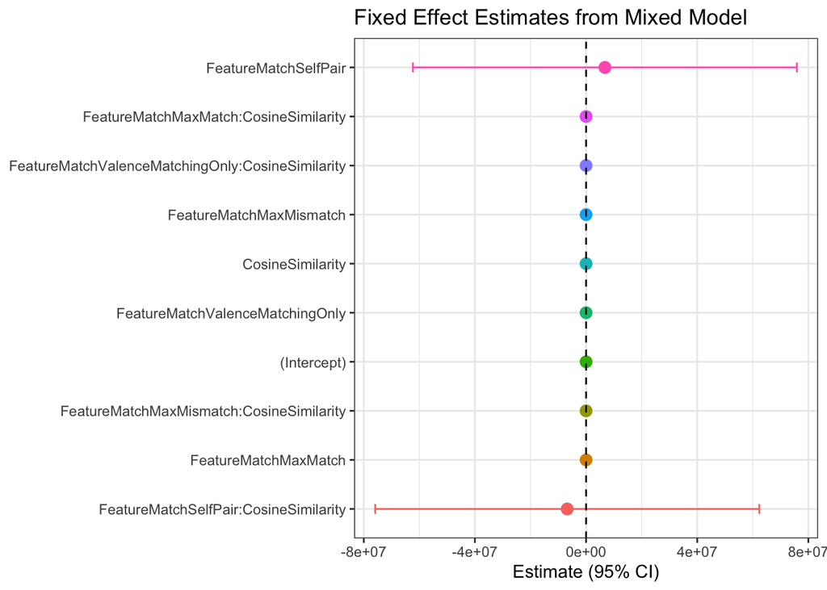

```r
# Tidy the model output
coefs <- tidy(m.full, effects = "fixed")

# Reorder by effect size for prettier plotting
coefs$term <- factor(coefs$term, levels = coefs$term[order(coefs$estimate)])

# Then replot
ggplot(coefs, aes(x = estimate, y = term, color = term)) +
  geom_point(size = 3) +
  geom_errorbarh(aes(xmin = estimate - 1.96 * std.error,
                     xmax = estimate + 1.96 * std.error), height = 0.2) +
  geom_vline(xintercept = 0, linetype = "dashed") +
  # theme_minimal(base_size = 14) +
  labs(title = "Fixed Effect Estimates from Mixed Model",
       x = "Estimate (95% CI)", y = NULL) +
  theme(legend.position="none")
```

## Word-2-Vec Similarity

```r
m.full <- lmer(cResponse ~ FeatureMatch*W2VSimilarity + (1|WordPair) + (1|ID.Ibex), data = dcen)
```

```
## fixed-effect model matrix is rank deficient so dropping 1 column / coefficient
```

```r
summary(m.full)
```

```
## Linear mixed model fit by REML. t-tests use Satterthwaite's method [
## lmerModLmerTest]
## Formula: cResponse ~ FeatureMatch * W2VSimilarity + (1 | WordPair) + (1 |
##     ID.Ibex)
##    Data: dcen
##
## REML criterion at convergence: 3745.2
##
## Scaled residuals:
##     Min      1Q  Median      3Q     Max
## -3.0100 -0.3995 -0.1133  0.2152  4.8842
##
## Random effects:
##  Groups   Name        Variance Std.Dev.
##  WordPair (Intercept) 125.25   11.191
##  ID.Ibex  (Intercept)  26.75    5.172
##  Residual             222.30   14.910
## Number of obs: 450, groups:  WordPair, 50; ID.Ibex, 9
##
## Fixed effects:
##                                               Estimate Std. Error      df
## (Intercept)                                    -27.625      9.909  43.306
## FeatureMatchMaxMatch                             9.458     11.823  41.000
## FeatureMatchMaxMismatch                          3.547     12.318  41.000
## FeatureMatchSelfPair                            62.139     50.107  41.000
## FeatureMatchValenceMatchingOnly                  7.749     11.430  41.000
## W2VSimilarity                                   33.815     58.764  41.000
## FeatureMatchMaxMatch:W2VSimilarity              40.981     64.460  41.000
## FeatureMatchMaxMismatch:W2VSimilarity          -44.622     87.158  41.000
## FeatureMatchValenceMatchingOnly:W2VSimilarity  -16.885     70.196  41.000
##                                               t value Pr(>|t|)
## (Intercept)                                    -2.788  0.00785 **
## FeatureMatchMaxMatch                            0.800  0.42836
## FeatureMatchMaxMismatch                         0.288  0.77483
## FeatureMatchSelfPair                            1.240  0.22198
## FeatureMatchValenceMatchingOnly                 0.678  0.50162
## W2VSimilarity                                   0.575  0.56814
## FeatureMatchMaxMatch:W2VSimilarity              0.636  0.52846
## FeatureMatchMaxMismatch:W2VSimilarity          -0.512  0.61142
## FeatureMatchValenceMatchingOnly:W2VSimilarity  -0.241  0.81111
```

[output cut: 9 more lines]

```
## W2VSimilrty      -0.904  0.758       0.727      -0.994  0.784
## FtrMtchMxMt:W2VS  0.824 -0.880      -0.663       0.906 -0.714 -0.912
## FtrMtchMxMs:W2VS  0.609 -0.511      -0.877       0.670 -0.528 -0.674
## FtMVMO:W2VS       0.757 -0.634      -0.609       0.832 -0.872 -0.837
##                  FtrMtchMxMt:W2VS FtrMtchMxMs:W2VS
## FtrMtchMxMt
## FtrMtchMxMs
## FtrMtchSlfP
## FtrMtchVlMO
## W2VSimilrty
## FtrMtchMxMt:W2VS
## FtrMtchMxMs:W2VS  0.615
## FtMVMO:W2VS       0.763            0.564
## fit warnings:
## fixed-effect model matrix is rank deficient so dropping 1 column / coefficient
```

```r
m.s <- lmer(cResponse ~ FeatureMatch + (1|WordPair) + (1|ID.Ibex), data = dcen)
```

## Does adding Word-2-Vec Similarity explain any more variance in the data?

```r
anova(m.s, m.full, REML=FALSE)
```

```
## refitting model(s) with ML (instead of REML)
```

```
## Data: dcen
## Models:
## m.s: cResponse ~ FeatureMatch + (1 | WordPair) + (1 | ID.Ibex)
## m.full: cResponse ~ FeatureMatch * W2VSimilarity + (1 | WordPair) + (1 | ID.Ibex)
##        npar    AIC    BIC  logLik deviance  Chisq Df Pr(>Chisq)
## m.s       8 3830.8 3863.7 -1907.4   3814.8
## m.full   12 3829.5 3878.8 -1902.7   3805.5 9.3499  4    0.05292 .
## ---
## Signif. codes:  0 '***' 0.001 '**' 0.01 '*' 0.05 '.' 0.1 ' ' 1
```

### Plot fixed effect estimates with confidence intervals

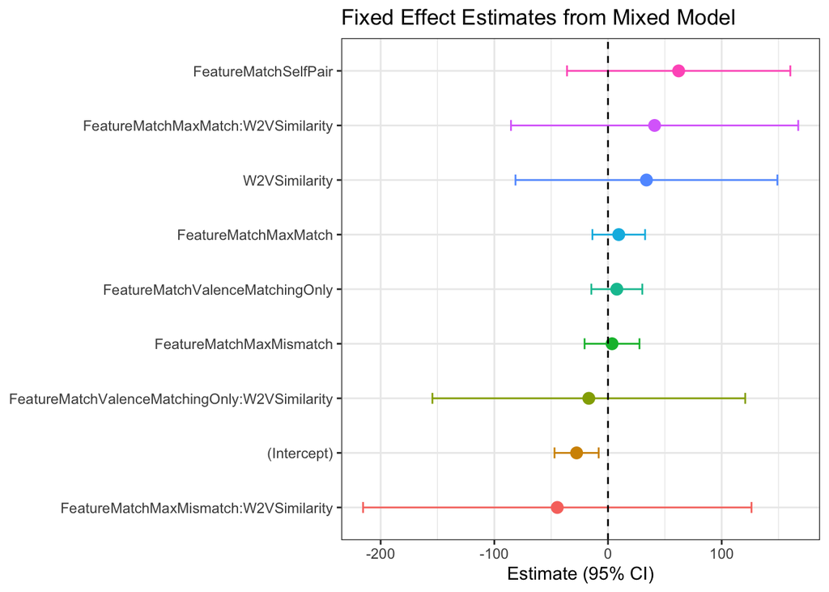

```r
# Tidy the model output
coefs <- tidy(m.full, effects = "fixed")

# Reorder by effect size for prettier plotting
coefs$term <- factor(coefs$term, levels = coefs$term[order(coefs$estimate)])

# Then replot
ggplot(coefs, aes(x = estimate, y = term, color = term)) +
  geom_point(size = 3) +
  geom_errorbarh(aes(xmin = estimate - 1.96 * std.error,
                     xmax = estimate + 1.96 * std.error), height = 0.2) +
  geom_vline(xintercept = 0, linetype = "dashed") +
  # theme_minimal(base_size = 14) +
  labs(title = "Fixed Effect Estimates from Mixed Model",
       x = "Estimate (95% CI)", y = NULL) +
  theme(legend.position="none")
```

### Plot predicted values vs. predictors

You can create a dataset of predicted values from your model and plot how the response changes with predictors:

1. Create a new dataset with combinations of predictors
- Generates all combinations of levels of FeatureMatch (a factor) and a sequence of W2VSimilarity values from -0.01 to 1 (100 points).
- Because: You want to predict your response across a continuous range of W2VSimilarity for each FeatureMatch group.

```r
newdata <- expand.grid(
  FeatureMatch = levels(dcen$FeatureMatch),
  W2VSimilarity = seq(-0.01, 1, length.out = 100)
)
```

2. Get predicted values and standard errors from the model

```r
pred <- predict(m.full, newdata = newdata, re.form = NA, se.fit = TRUE)
```

3. Add predictions and confidence intervals to newdata

```r
newdata$fit <- pred$fit
newdata$se <- pred$se.fit
newdata <- newdata %>%
  mutate(
    conf.low = fit - 1.96 * se,
    conf.high = fit + 1.96 * se
  )
```

4. Plot predicted lines with ribbons for confidence intervals

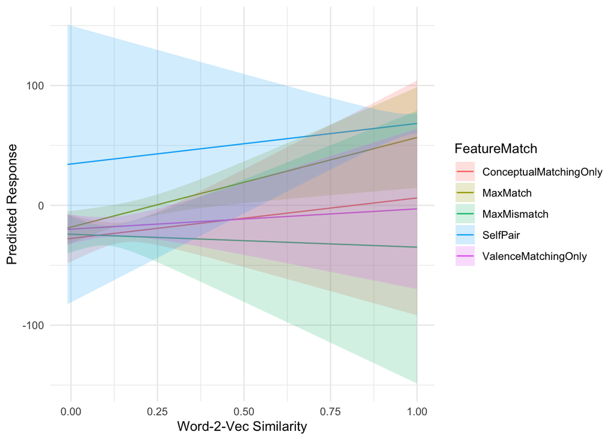

```r
ggplot(newdata, aes(x = W2VSimilarity, y = fit, color = FeatureMatch, fill = FeatureMatch)) +
  geom_line() +
  geom_ribbon(aes(ymin = conf.low, ymax = conf.high), alpha = 0.2, color = NA) +
  theme_minimal() +
  labs(x = "Word-2-Vec Similarity", y = "Predicted Response", color = "FeatureMatch", fill = "FeatureMatch")
```

### Visualize individual random effect estimates:

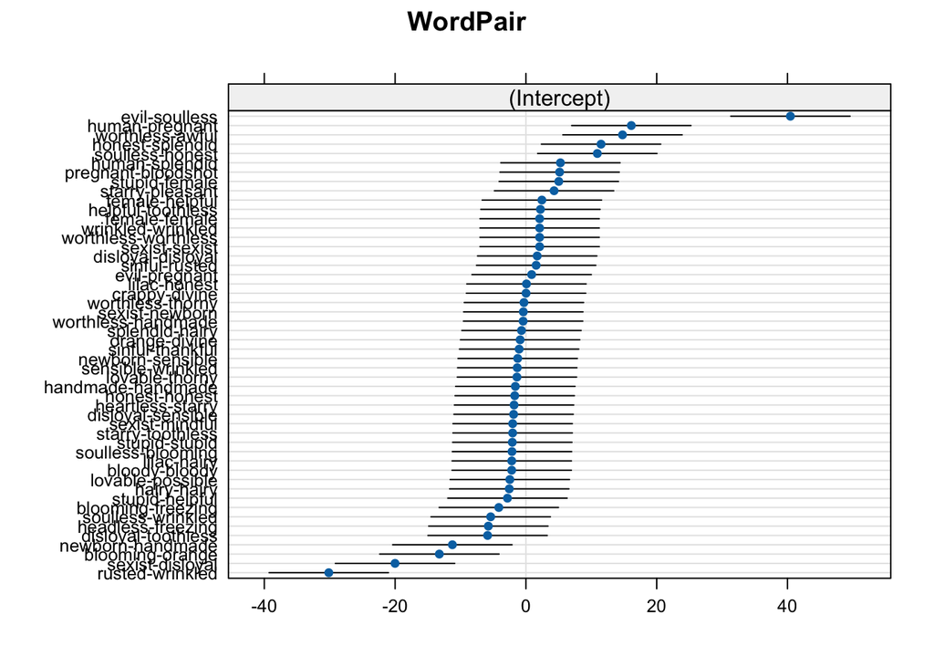

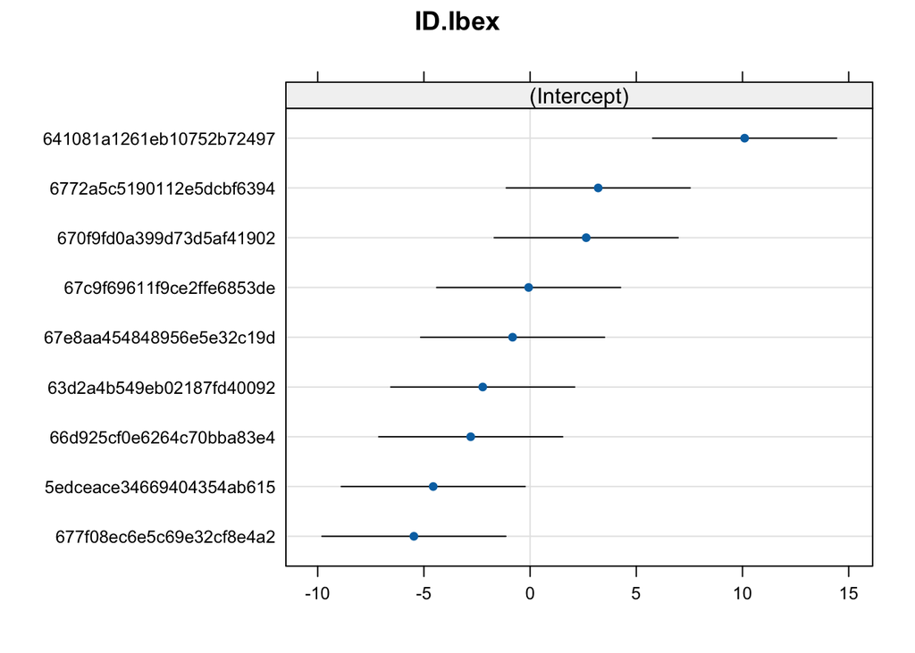

```r
dotplot(ranef(m.full, condVar=TRUE))
```

### Check model diagnostics

For residuals, fitted vs residuals, etc.:

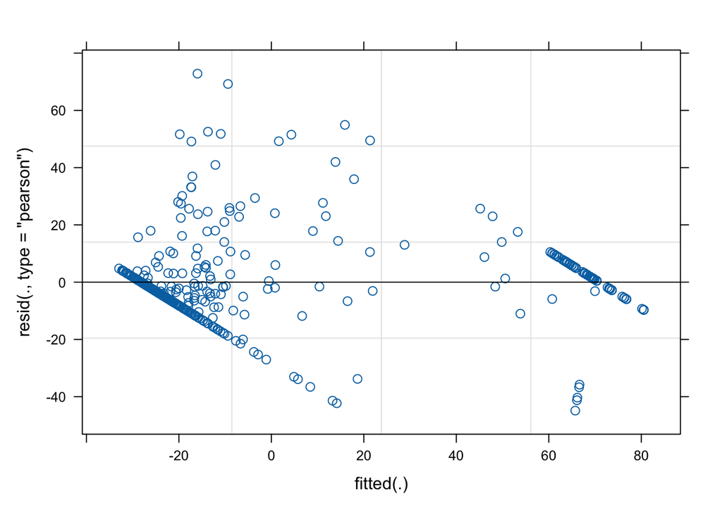

```r
plot(m.full)
```

# Similarity Alone

```r
m <- lmer(cResponse ~ W2VSimilarity + (1|WordPair) + (1|ID.Ibex), data = dcen)
summary(m)
```

```
## Linear mixed model fit by REML. t-tests use Satterthwaite's method [
## lmerModLmerTest]
## Formula: cResponse ~ W2VSimilarity + (1 | WordPair) + (1 | ID.Ibex)
##    Data: dcen
##
## REML criterion at convergence: 3814.3
##
## Scaled residuals:
##     Min      1Q  Median      3Q     Max
## -2.9891 -0.4047 -0.1325  0.2249  4.8752
##
## Random effects:
##  Groups   Name        Variance Std.Dev.
##  WordPair (Intercept) 158.59   12.593
##  ID.Ibex  (Intercept)  26.75    5.172
##  Residual             222.30   14.910
## Number of obs: 450, groups:  WordPair, 50; ID.Ibex, 9
##
## Fixed effects:
##               Estimate Std. Error      df t value Pr(>|t|)
## (Intercept)    -30.689      3.085  37.818  -9.948 4.16e-12 ***
## W2VSimilarity   97.392      5.384  48.000  18.089  < 2e-16 ***
## ---
## Signif. codes:  0 '***' 0.001 '**' 0.01 '*' 0.05 '.' 0.1 ' ' 1
##
## Correlation of Fixed Effects:
##             (Intr)
## W2VSimilrty -0.550
```

```r
m <- lmer(cResponse ~ CosineSimilarity + (1|WordPair) + (1|ID.Ibex), data = dcen)
summary(m)
```

```
## Linear mixed model fit by REML. t-tests use Satterthwaite's method [
## lmerModLmerTest]
## Formula: cResponse ~ CosineSimilarity + (1 | WordPair) + (1 | ID.Ibex)
##    Data: dcen
##
## REML criterion at convergence: 3812.9
##
## Scaled residuals:
##     Min      1Q  Median      3Q     Max
## -3.0028 -0.4074 -0.1465  0.1969  4.9045
##
## Random effects:
##  Groups   Name        Variance Std.Dev.
##  WordPair (Intercept) 154.47   12.429
##  ID.Ibex  (Intercept)  26.75    5.172
##  Residual             222.30   14.910
## Number of obs: 450, groups:  WordPair, 50; ID.Ibex, 9
##
## Fixed effects:
##                  Estimate Std. Error      df t value Pr(>|t|)
## (Intercept)       -47.201      3.632  47.309  -13.00   <2e-16 ***
## CosineSimilarity  115.351      6.294  48.000   18.33   <2e-16 ***
## ---
## Signif. codes:  0 '***' 0.001 '**' 0.01 '*' 0.05 '.' 0.1 ' ' 1
##
## Correlation of Fixed Effects:
##             (Intr)
## CosinSmlrty -0.709
```